# ALE Data exploration

Kenzie Cooke

2025-03-10

# 1 Quality Control of carbonate chemistry

Alkalinity bottle sample quality. Each sample is run in replicate for quality control. If the replicates are within an acceptable threshold (usually < 5umol difference), then the mean of the replicates is used as the final TA value for that sample. The difference in umol between each replicate (deltas) for all collected samples are plotted below

## 1.1 Instrument precision (replicate deltas)

### 1.1.1 AllBottles_delta(umol)

Histogram depicts deltas between replicates of all 526 alkalinity samples collected for from February 7th to March 19th, 2024

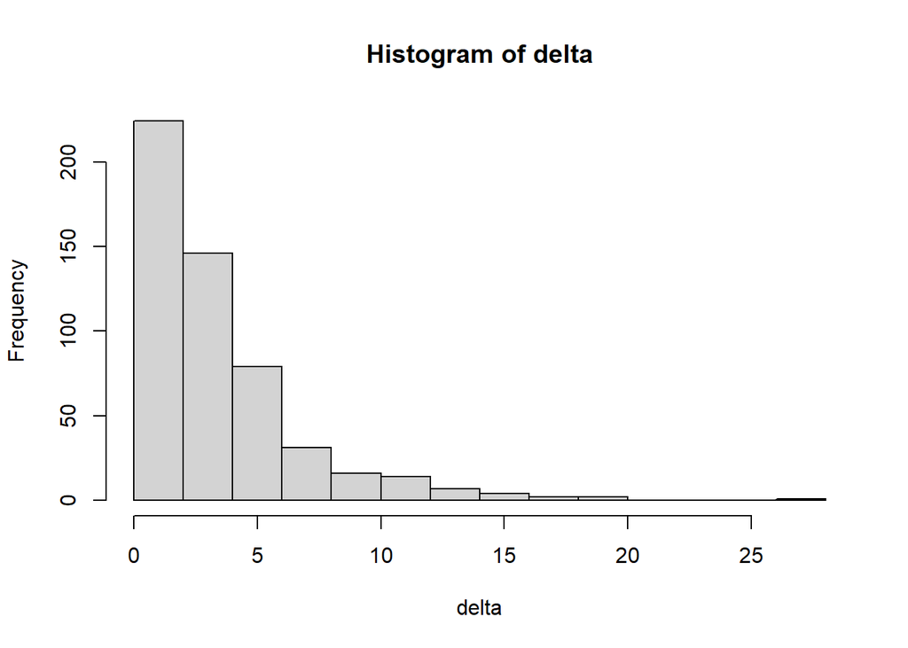

### 1.1.2 Deltas by treatment

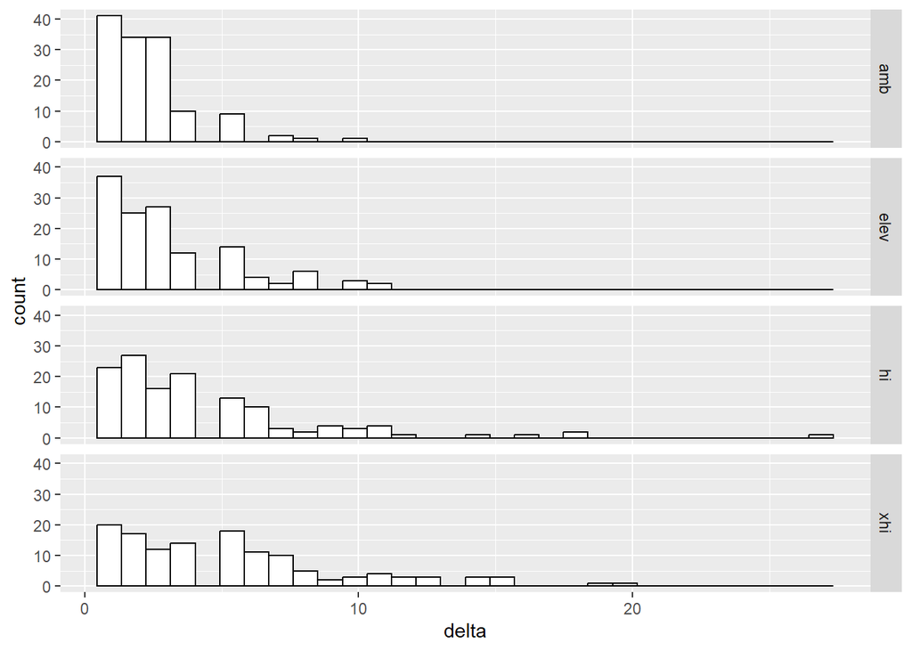

### 1.1.3 deltas > 5 umol by treatment

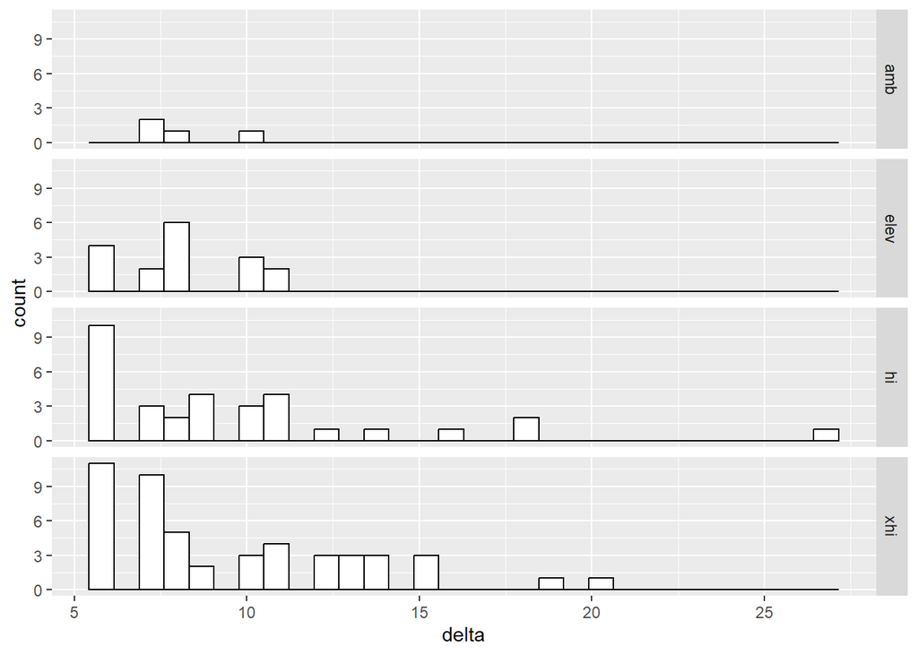

## 1.2 Precipitation

### 1.2.1 PrecipitatedSamples_treatment

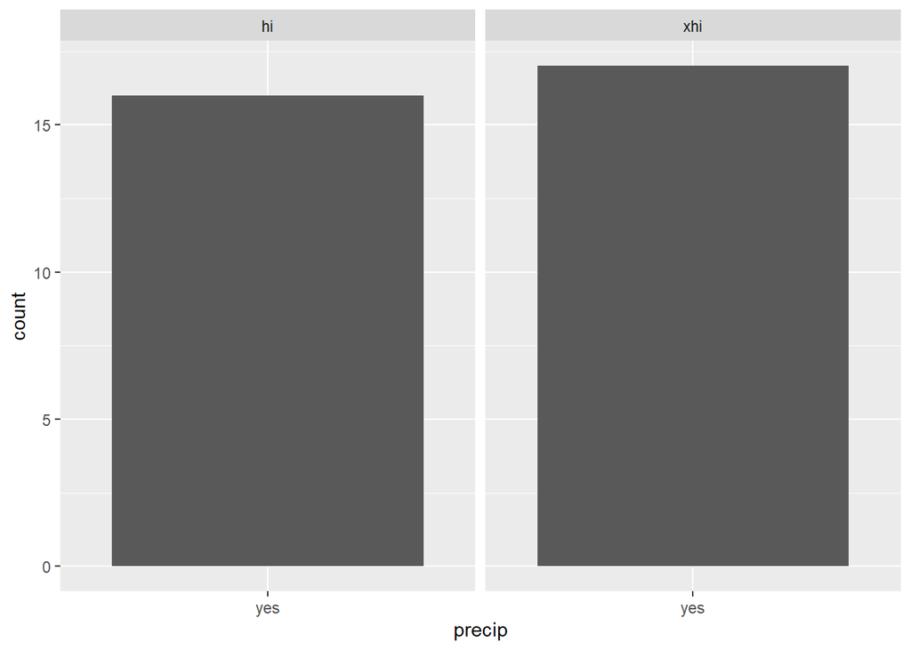

number of samples with confirmed visual precipitation in bottles post collection. Not confident that all samples with precipitatin were noted down.

### 1.2.2 Number of samples with suspicious pCO2 values

Carbchem parameters generated using all bottle samples (DIC and TA)

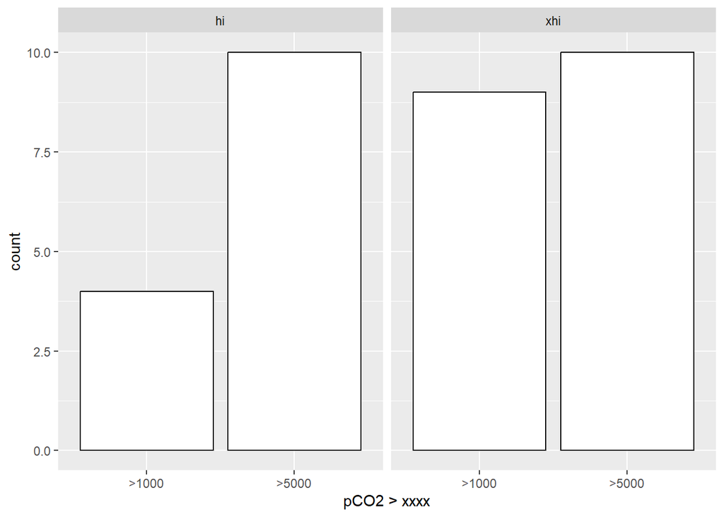

Datapoints where computed pCO2 (using DIC and TA in seacarb) produced suspicious values (likely due to visible precipitation in bottle samples post collection)

## 1.3 Stability of treatments over time

### 1.3.1 AmbientTreat_time

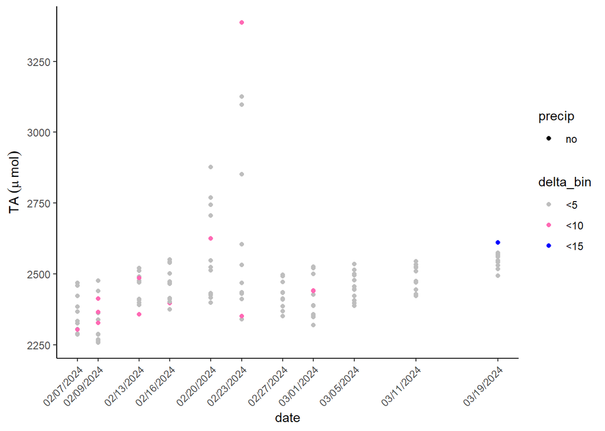

Ambient treatment over time using all bottle sample data

### 1.3.2 ElevatedTreat_time

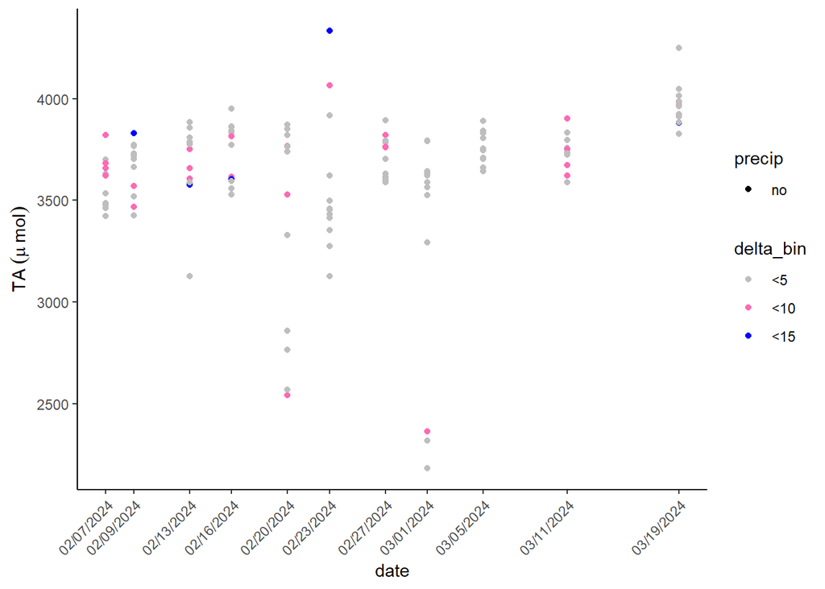

### 1.3.3 HighTreat_time

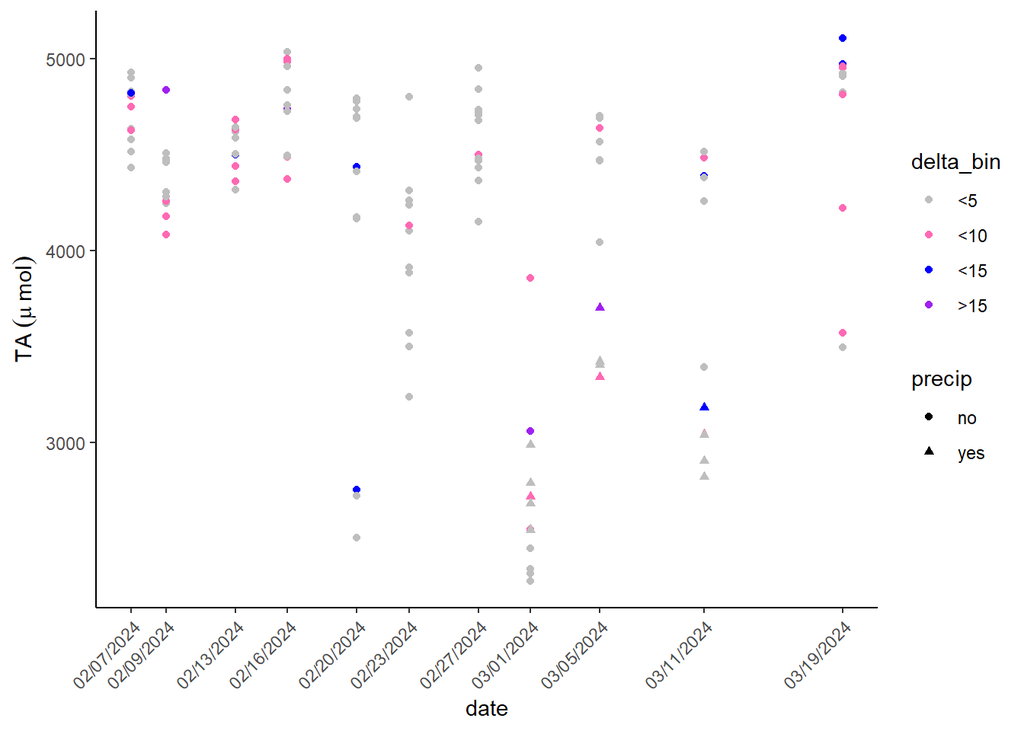

### 1.3.4 XhiTreat_time

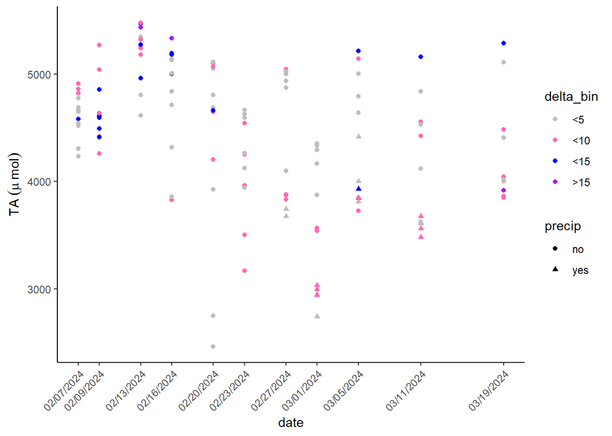

### 1.3.5 TA_Time (precipitation excluded, >5umol delta excluded)

Break down of remaining samples:

ambient 128

elevated 114

hi 87

xhi 67

Updated plots below. Can see that in the hi and extra high treamtents, gets as low as four samples per time point towards the end of the experiment (down from 12 per tiempoint per treatment).

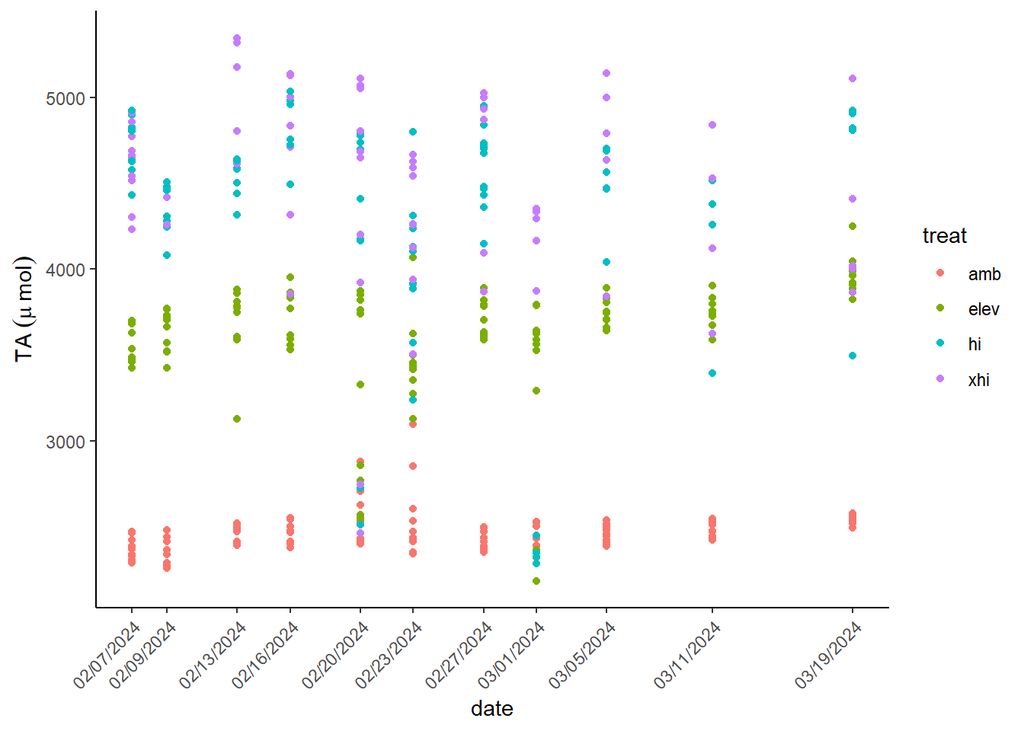

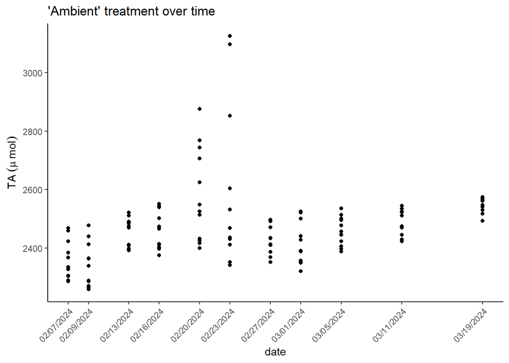

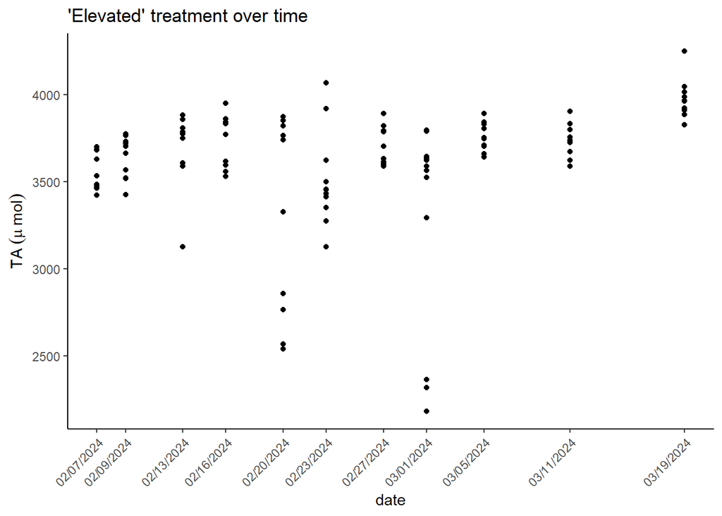

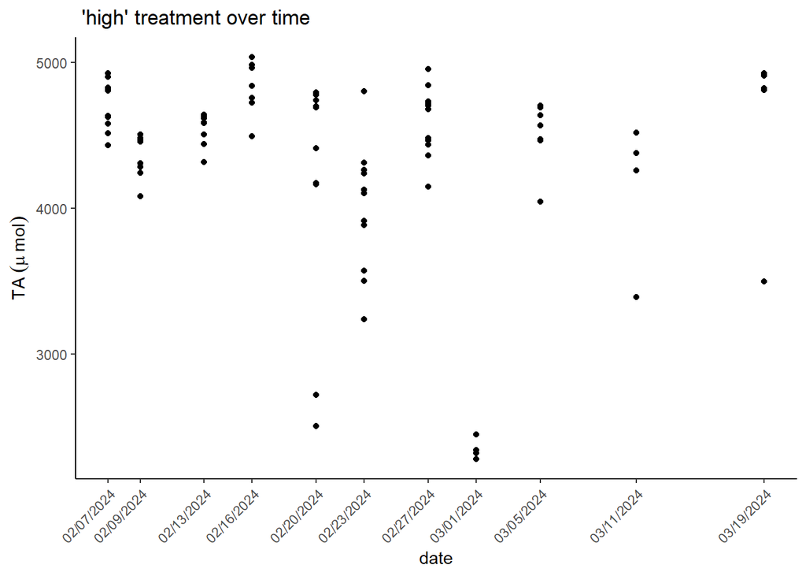

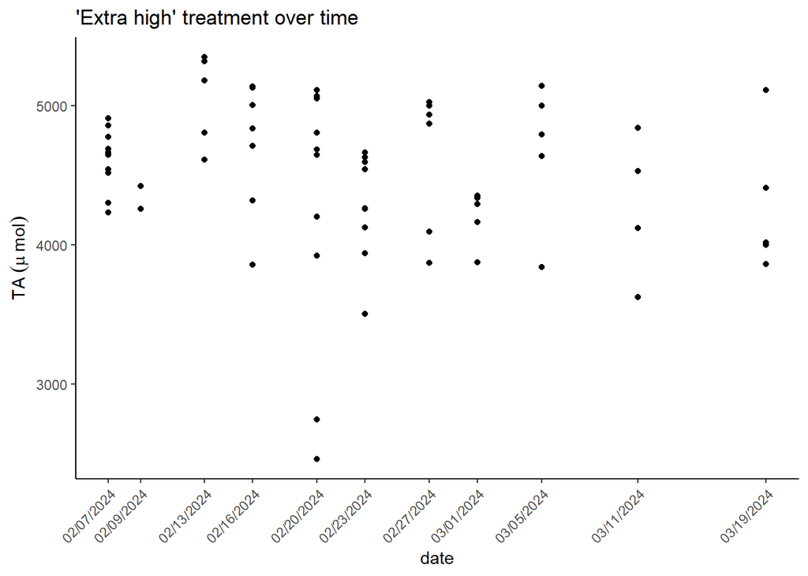

# 2 QC Growth rates

Took timepoint 0 on Feb 3rd. Corals were placed in vessels and ramped up to treatment levels for four days. Were at full treatment dosage on Feb 7. Noticed the lights were not set to the same parameters on Feb 15th. Corrected and took new datapoint on Feb 19th (T1). Took another point on March 8th (T2) and endpoint on March 23rd (T3).

## 2.1 Growth rates over time

### 2.1.1 Total calcification growth rates across timepoints

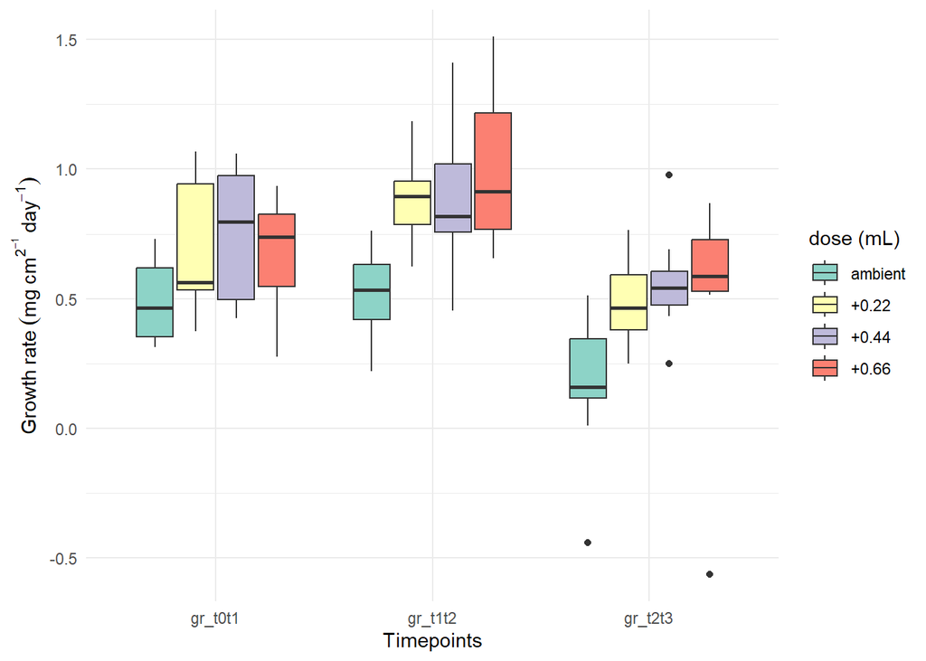

total calcificaiton growth rates across timepoints

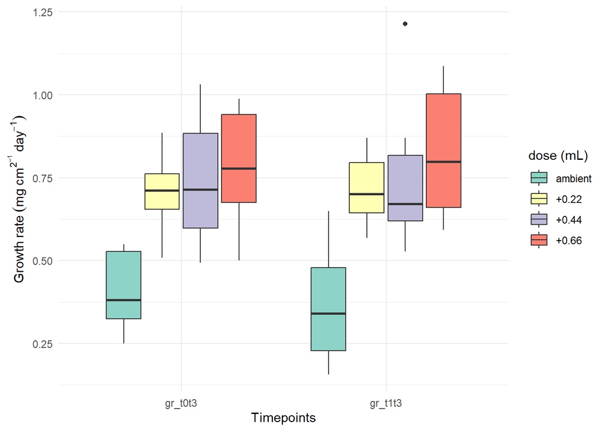

Using initial timepoint zero to end (left) vs. using second timepoint zero to end (right)

### 2.1.2 Linear extension

#### 2.1.2.1 Standards

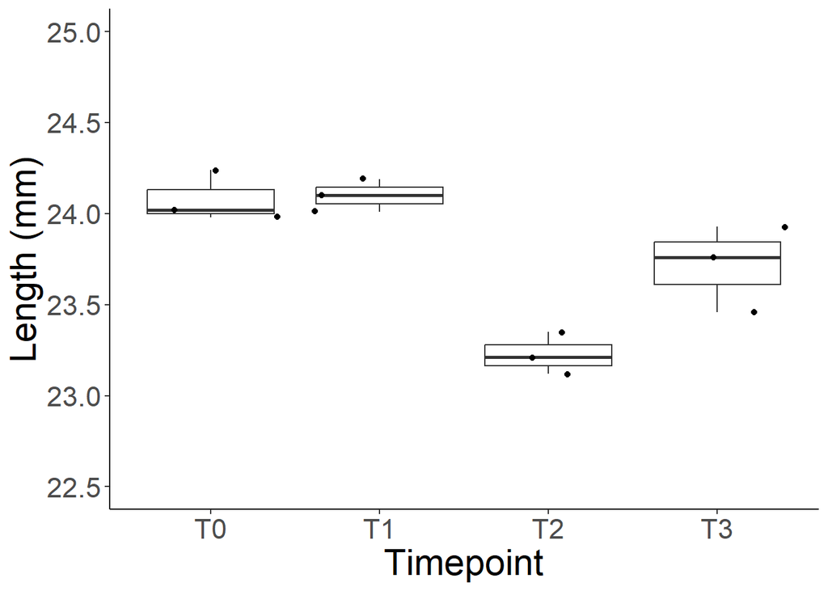

Measured a standard in three photos from each timepoint to check precision/accuracy of imageJ method across timepoints

Across all timepoints, the ImageJ method has a standard deviation of ± 0.39 mm and a standard error of ± 0.11 mm.

#### 2.1.2.2 Linear extension growth rates across timepoints

You’ll notice a a few negative rates from t2 to t3. The -0.4 mm/day rate comes from a coral that died three days after timepoint and it had a -1.47 mm difference in total length between tp2 and 3. I am going to maybe re-analyze the photos from timepoint 2.

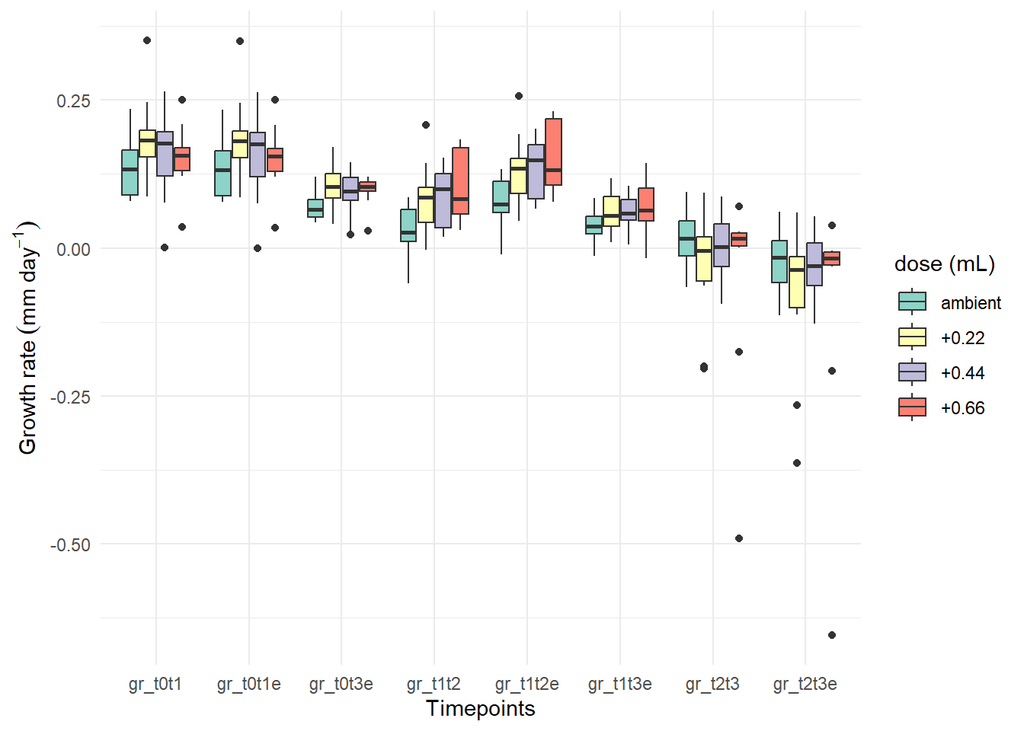

linear extension growth rates across all timepoints. Going to investigate the super negative rates.

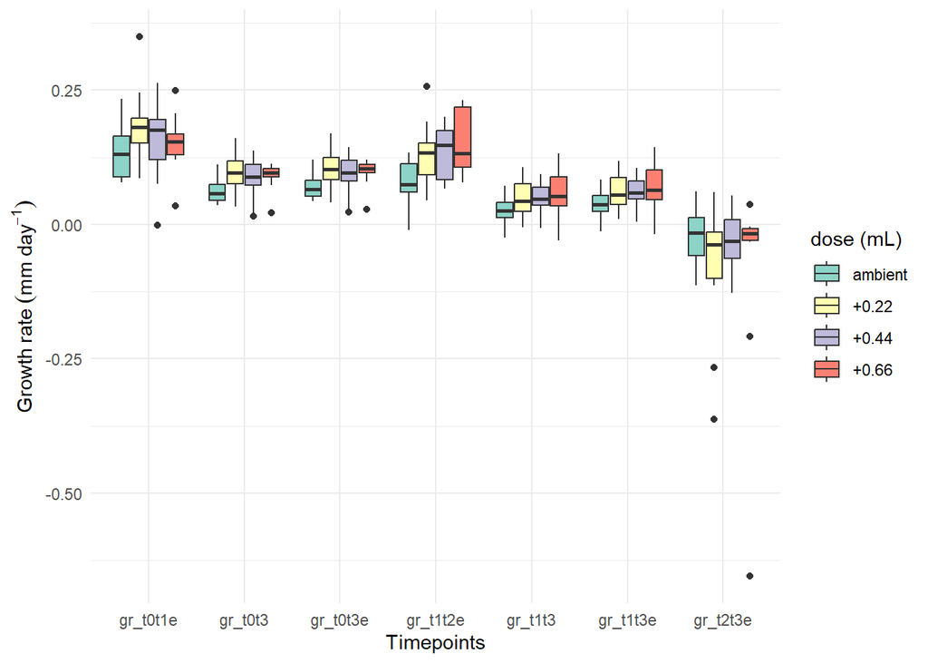

Using initial timepoint zero - end (left) vs. using second timeppoint zero to end (right)

### 2.1.3 Linear extension with offset correction

Growth results with linear extension offset applied to each timepoint. Took the mean standard length of timepoint 1 and (24.1 mm) and calculated offset for each timepoint that would bring the mean to 24.1 mm.

t0 = offset of +0.02 mm  
t1 = no offset  
t2 = offset of + 0.873 mm  
t3 = offset of + 0.383 mm

Comparing growth rates withdout and with the offset applied (gr_t0t1 vs grt0t1e) “e” standing for edited.

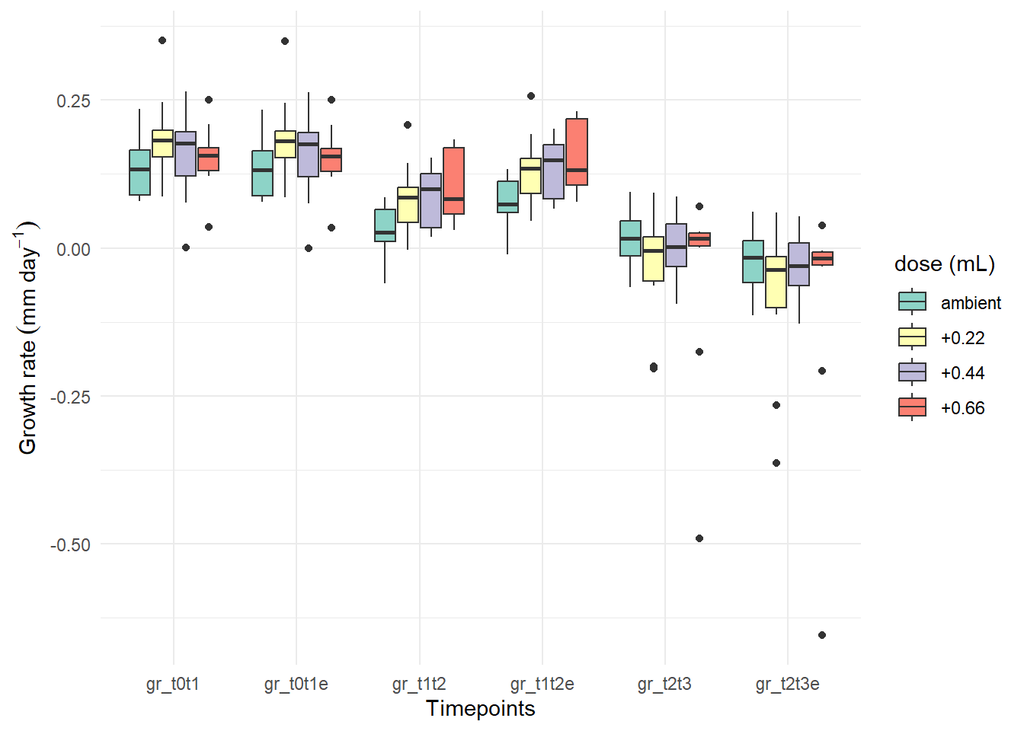

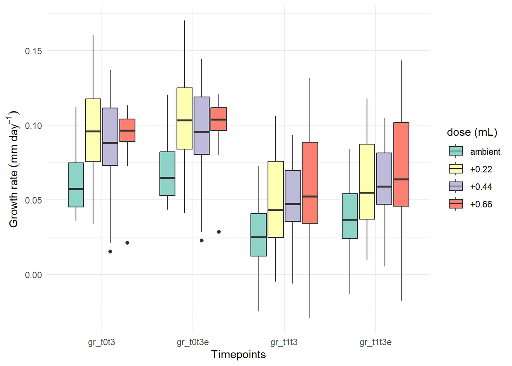

# 3 Results

## 3.1 Fv/Fm

```
##             Df  Sum Sq  Mean Sq F value Pr(>F)
## treatment    3 0.00901 0.003002   2.123  0.119
## Residuals   29 0.04101 0.001414
```

Data analysis using bottle data excluding deltas > or equal to 5 umol and any with precipitation.

## 3.2 Carb chem parameters

Carb chem parameters generated using seacarb with measured DIC and TA values. Includes samples from 2/3 - 3/23.

###Coral beakers

### 3.2.1 Blank Beakers

###Print carb chem data

### 3.2.2 ANOVA_treatments

Was alkalinity statistically different between treatments?

```
##             Df Sum Sq Mean Sq F value Pr(>F)
## treatment    3 25.830   8.610   241.1 <2e-16 ***
## Residuals   36  1.285   0.036
## ---
## Signif. codes:  0 '***' 0.001 '**' 0.01 '*' 0.05 '.' 0.1 ' ' 1
```

```
##
## Call:
## lm(formula = avg_ta_mmol ~ treatment, data = grdata)
##
## Residuals:
##      Min       1Q   Median       3Q      Max
## -0.47221 -0.07392 -0.01059  0.12393  0.29886
##
## Coefficients:
##               Estimate Std. Error t value Pr(>|t|)
## (Intercept)    2.45397    0.05975   41.07  < 2e-16 ***
## treatmentELEV  1.19744    0.08451   14.17 2.69e-16 ***
## treatmentHI    1.90455    0.08451   22.54  < 2e-16 ***
## treatmentXHI   2.02008    0.08451   23.91  < 2e-16 ***
## ---
## Signif. codes:  0 '***' 0.001 '**' 0.01 '*' 0.05 '.' 0.1 ' ' 1
##
## Residual standard error: 0.189 on 36 degrees of freedom
## Multiple R-squared:  0.9526, Adjusted R-squared:  0.9486
## F-statistic: 241.1 on 3 and 36 DF,  p-value: < 2.2e-16
```

```
##  treatment emmean     SE df lower.CL upper.CL .group
##  AMB         2.45 0.0598 36     2.33     2.58  a
##  ELEV        3.65 0.0598 36     3.53     3.77   b
##  HI          4.36 0.0598 36     4.24     4.48    c
##  XHI         4.47 0.0598 36     4.35     4.60    c
##
## Confidence level used: 0.95
## P value adjustment: tukey method for comparing a family of 4 estimates
## significance level used: alpha = 0.05
## NOTE: If two or more means share the same grouping symbol,
##       then we cannot show them to be different.
##       But we also did not show them to be the same.
```

All treatments statistically different from eachother (p < 0.000) except for the extra high and high treatments (p = 0.68)

### 3.2.3 Stability of treatment over time

#### 3.2.3.1 TA by treatment barplot and boxplot

```
## # A tibble: 4 × 3
##   Treatment mean_ta sem_ta
##   <fct>       <dbl>  <dbl>
## 1 AMB         2469.   12.8
## 2 ELEV        3653.   26.4
## 3 HI          4355.   67.6
## 4 XHI         4525.   69.4
```

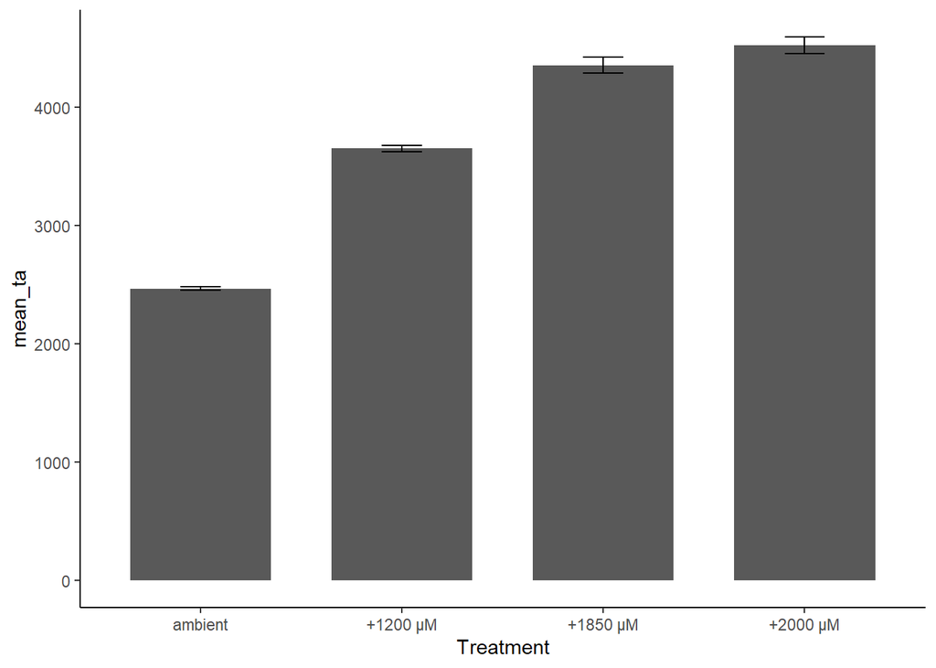

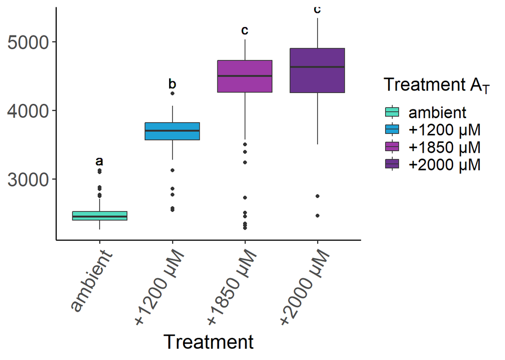

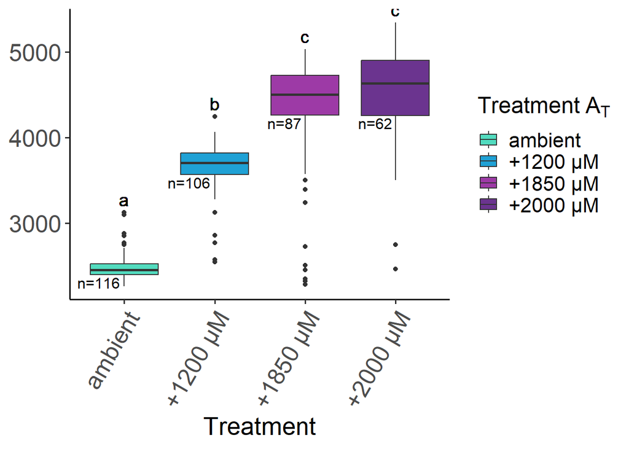

#### Treatment stability over time

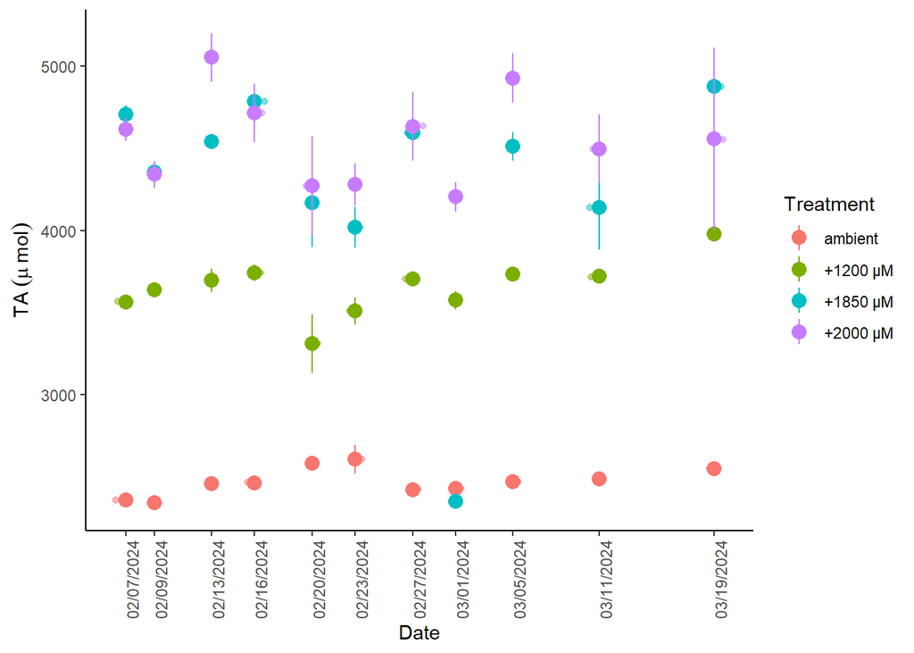

#### 3.2.3.2 TreatStability_Time_AllDataPoints

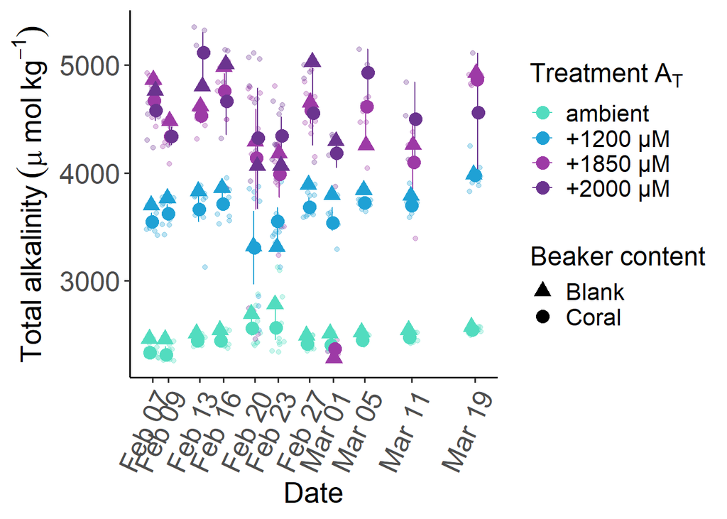

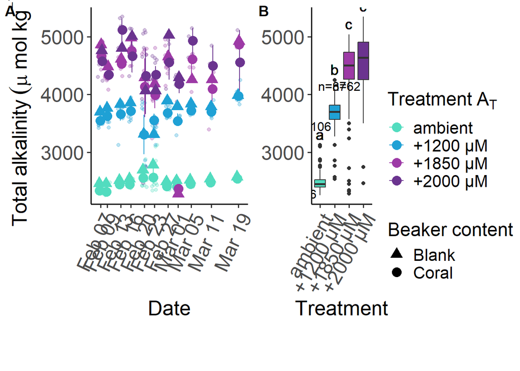

### 3.2.4 Blanks

Total alkalinity in blanks by treatment

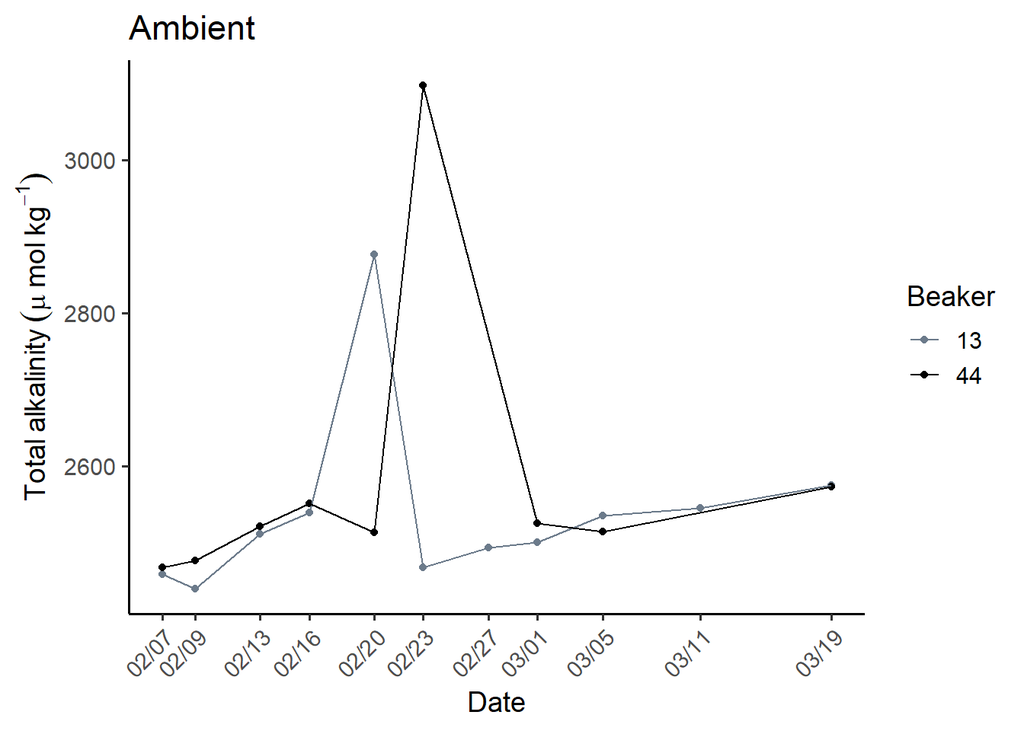

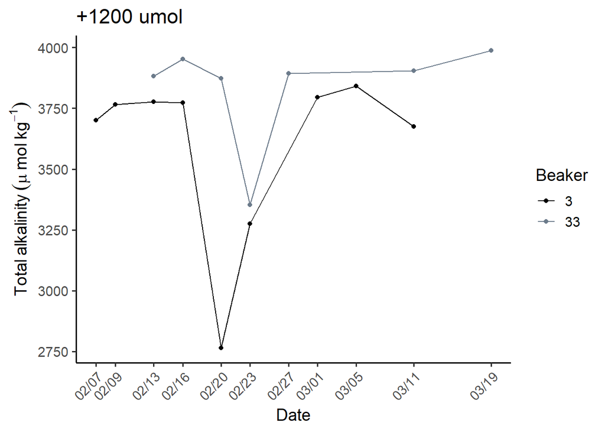

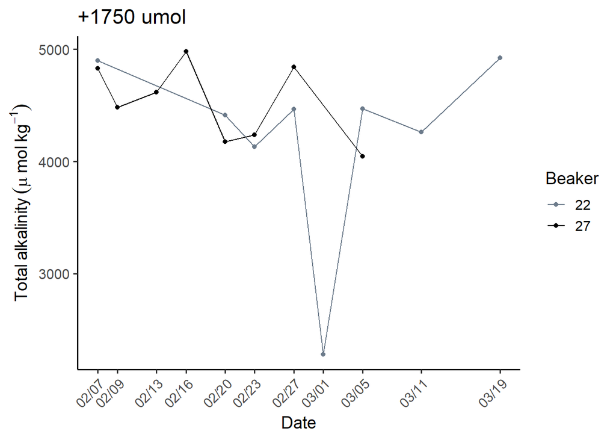

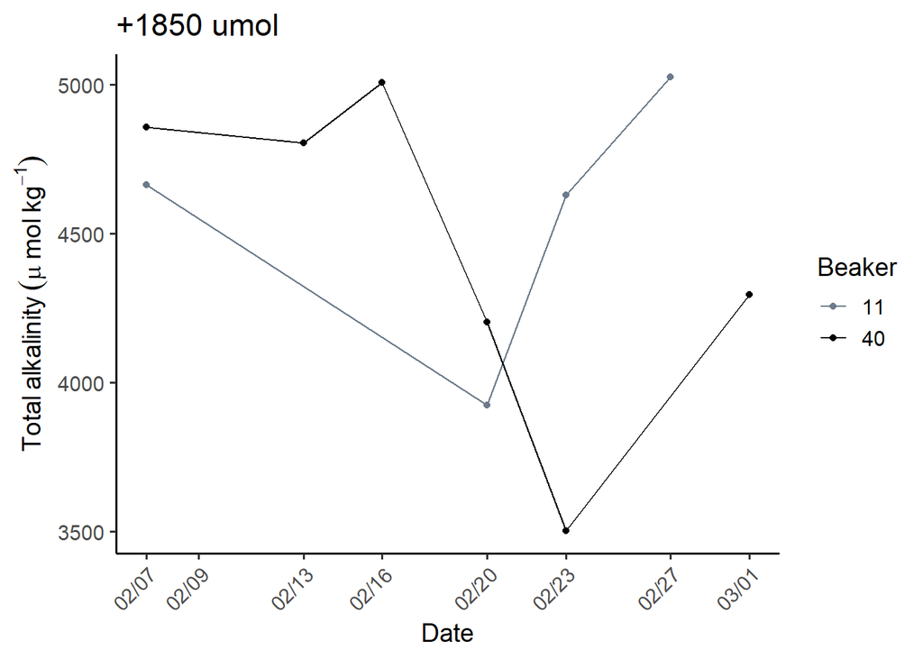